# Metrics

Peter

Friday, March 27, 2015

# Overview:

This document is created to give a brief summary of the possibilities to use R for calculating and reporting the metrics of a department within operations. At this moment there are 3 main elements that are used to “grade”" the performance of a department/team/agent, which will be discussed in this document, namely:

- Average number of cases handled per shift
- Average case Handle Time in minutes
- Customer Satisfaction scores

As an addition, several extra plots are added to show:

- The number of cases per language
- The handle time per language, split in Email and Chat
- The number of cases handled per agent grouped by language
- The waiting time (in queue) per language, split in Email and Chat

For this document 3 data sets are created:

1. Pay2 (cases and there main features)
2. CusSat (customer feedback per caseID, NoProduct, NoPolicy and NoAgent mean that there is dissatisfaction due to product, policy or agent.)
3. Time (time registating per agent, hours worked versus TA/sickness)

```r
Pay2 <- read.csv("C:/Users/User/Desktop/Pay2.csv", sep=";")
kable(head(Pay2), format = "latex")
```

[output not shown]

```r
CusSat <- read.csv("C:/Users/User/Desktop/CusSat.csv", sep=";")
kable(head(CusSat), format = "latex")
```

[output not shown]

```r
time <- read.csv("C:/Users/User/Desktop/Time.csv", sep=";")
Time <- data.frame(time)
kable(head(Time), format = "latex")
```

[output not shown]

# *The first element is the number of cases handled per shift.*

```r
EE <-  Pay2 %>%
  group_by(Agent) %>%
  summarise(NumberOfCases = n())

TA <- Time %>%
  group_by(Agent) %>%
  summarise(Shifts = sum(Netto.Hours, na.rm=TRUE)/8)

length(Pay2$Agent); AveCasesperShift<- length(Pay2$Agent)/sum(TA$Shifts)
```

- The overall number of cases handled is 99, done in an overall number of netto shifts of 21.875.
- This results in an average of 4.5257143 cases per shift.

The number of cases separated by agent gives:

```r
kable(EE)
```

| Agent | NumberOfCases |
| --- | --- |
| A1 | 23 |
| A2 | 31 |
| A3 | 20 |
| A4 | 25 |

The number of shifts separated by agent gives:

```r
kable(TA)
```

| Agent | Shifts |
| --- | --- |
| A1 | 4.000 |
| A2 | 5.625 |
| A3 | 6.250 |
| A4 | 6.000 |

The average number of cases per shift per agents:

```r
A1Cases<- length(Pay2$Agent[Pay2$Agent=="A1"])
A2Cases<- length(Pay2$Agent[Pay2$Agent=="A2"])
A3Cases<- length(Pay2$Agent[Pay2$Agent=="A3"])
A4Cases<- length(Pay2$Agent[Pay2$Agent=="A4"])

A1Shift <- TA[1, 2]
A2Shift <- TA[2, 2]
A3Shift <- TA[3, 2]
A4Shift <- TA[4, 2]

ScoreA1 <- A1Cases/A1Shift
ScoreA2 <- A2Cases/A2Shift
ScoreA3 <- A3Cases/A3Shift
ScoreA4 <- A4Cases/A4Shift
```

- Agent 1 handled an average of 5.75 cases per shifts.
- Agent 2 handled an average of 5.5111111 cases per shifts.
- Agent 3 handled an average of 3.2 cases per shifts.
- Agent 4 handled an average of 4.1666667 cases per shifts.

A plot of cases per agent per type:

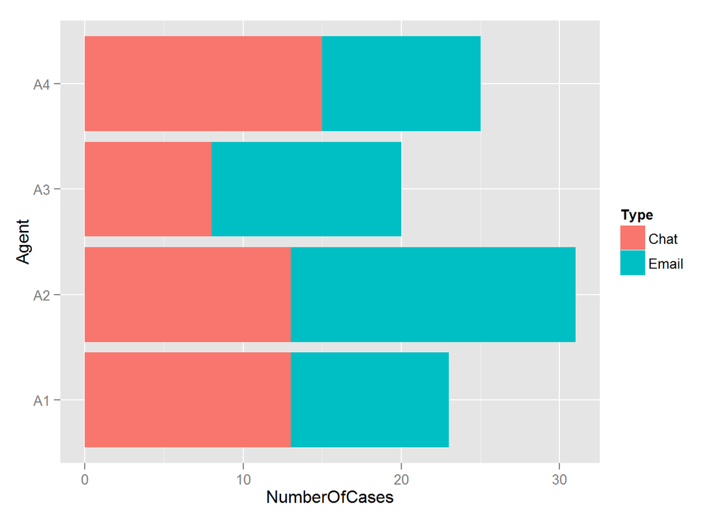

```r
PP <-  Pay2 %>%
  group_by(Agent, Type) %>%
  summarise(NumberOfCases = n())

ggplot(PP, aes(x=Agent, y=NumberOfCases, fill=Type)) +
  geom_bar(stat="identity") + coord_flip()
```

# *The second element is the Average Handle Time per case in minutes.*

Below the overall average Handle Time and the Handle Time per agent:

```r
mean(Pay2$HandleTime)
```

```
## [1] 6.060606
```

```r
HH <- Pay2 %>%
  group_by(Agent) %>%
  summarise(avg_handle = mean(HandleTime, na.rm=TRUE))

kable(HH)
```

| Agent | avg_handle |
| --- | --- |
| A1 | 6.521739 |
| A2 | 5.000000 |
| A3 | 7.250000 |
| A4 | 6.000000 |

A boxplot of the overall handle time of the team versus handle time per agent:

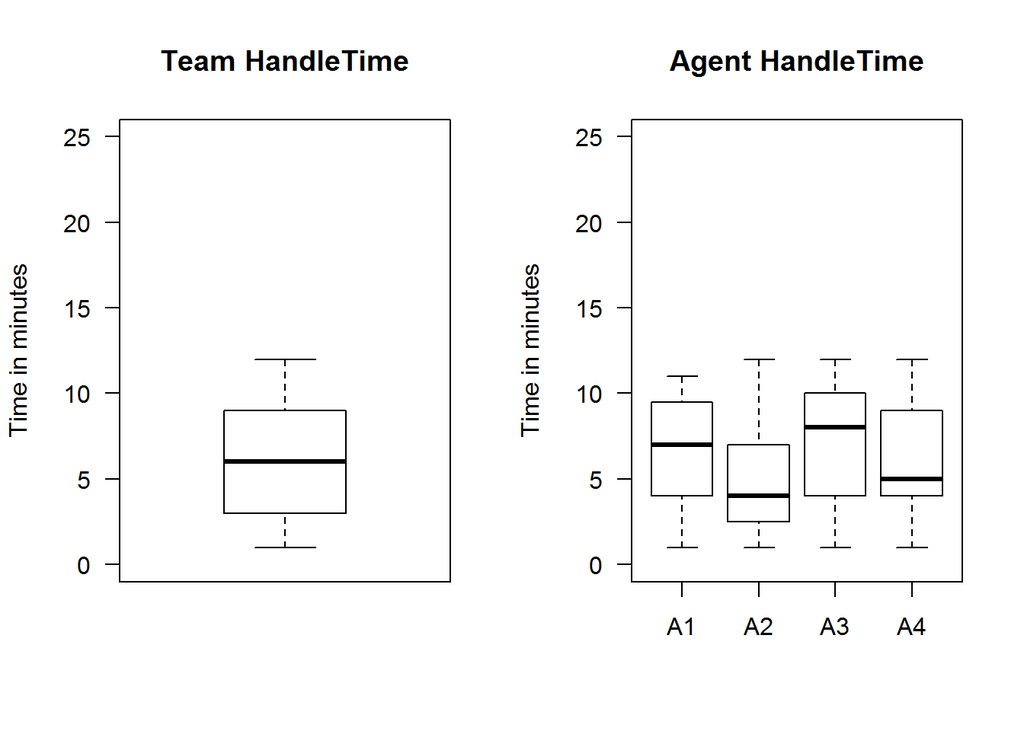

# *The third element is the Customer Satisfaction per Agent*

The set goal for a 3 rating is to have equal or less than 3% dissatisfaction.

Below a table with the number of “satified/Not agent to blame”" Customer reviews, versus the cases in which agent can be blamed.

And the same table expressed in percentages.

```
##
##       0  1
##   A1 27  1
##   A2 26  1
##   A3 26  1
##   A4 25  2
```

|  | 0 | 1 |
| --- | --- | --- |
| A1 | 0.9642857 | 0.0357143 |
| A2 | 0.9629630 | 0.0370370 |
| A3 | 0.9629630 | 0.0370370 |
| A4 | 0.9259259 | 0.0740741 |

# *The number of cases per language:*

```r
YY <-Pay2 %>%
  group_by(Language) %>%
  summarise(lang_count = n()) %>%
  arrange(desc(lang_count))
kable(YY)
```

| Language | lang_count |
| --- | --- |
| English | 28 |
| Portuguese | 21 |
| Russian | 21 |
| Spanish | 14 |
| Dutch | 8 |
| Italian | 7 |

In a barchart:

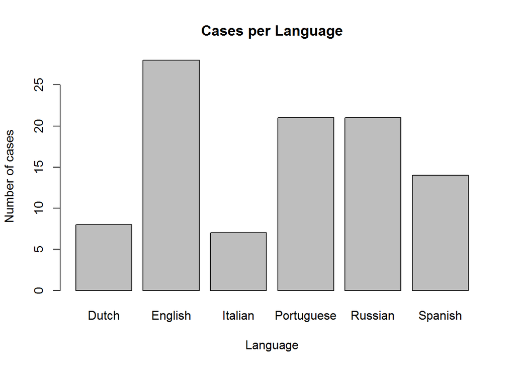

```r
y=table(Pay2$Language)

barplot(y, main="Cases per Language", xlab="Language", ylab="Number of cases")
```

# *The handle time per language, split in Email and Chat:*

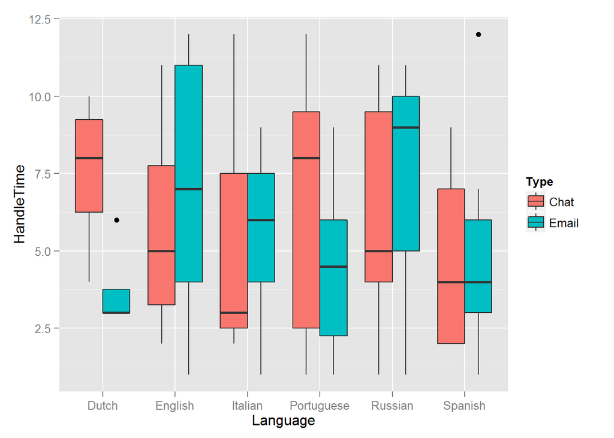

```r
a <- ggplot(Pay2, aes(y=HandleTime, x=Language, fill=Type))  + geom_boxplot()
a
```

# *The number of cases handled per agent grouped by language:*

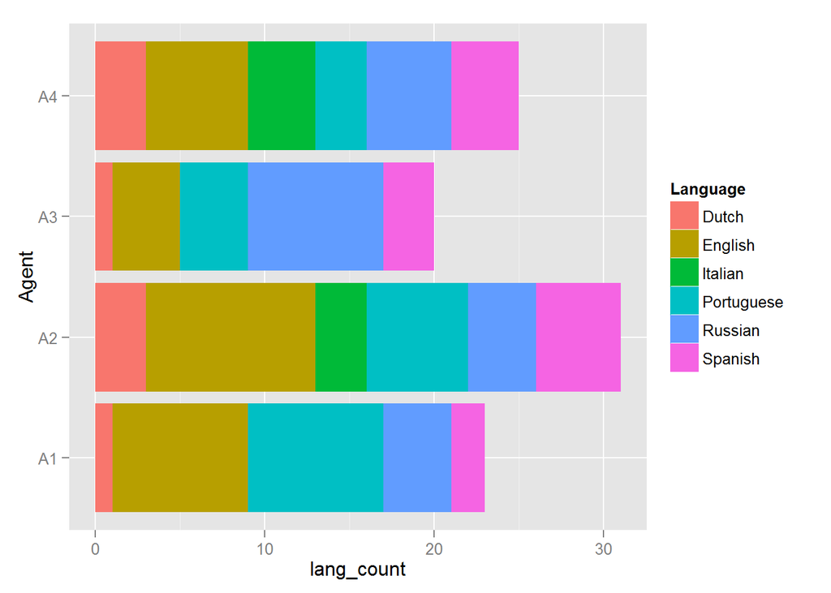

```r
FF <-Pay2 %>%
  group_by(Agent, Language) %>%
  summarise(lang_count = n())

ggplot(FF, aes(x=Agent, y=lang_count, fill=Language)) +
  geom_bar(stat="identity") + coord_flip()
```

# *The waiting time (in queue) per language, split in Email and Chat:*

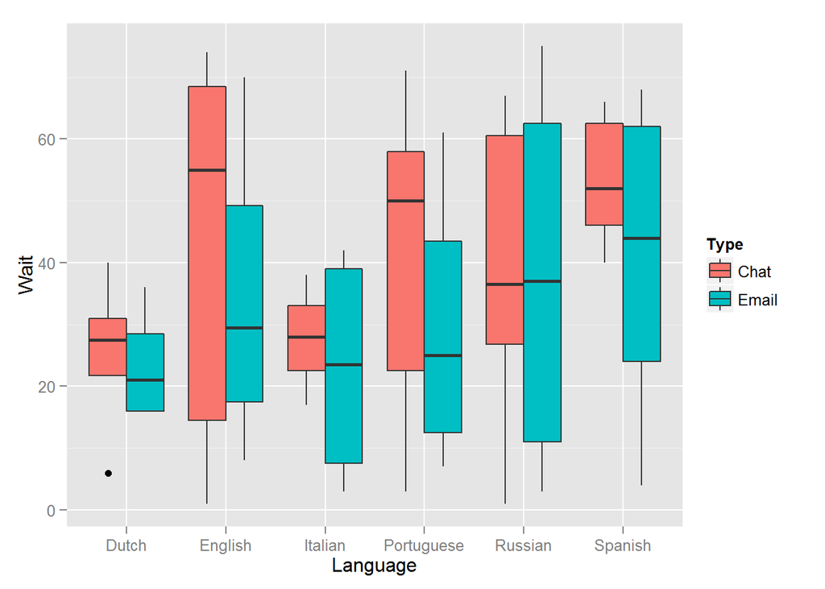

```r
b <- ggplot(Pay2, aes(y=Wait, x=Language, fill=Type))  + geom_boxplot()
b
```